# Mi Dataset

Generado el 2026-03-20 09:47:47 · 14,780 filas · 15 columnas

## 📊 Resumen General

Filas

14,780

Columnas

15

Numéricas

10

Categóricas

5

Nulos

8.1%

18,000 celdas

Duplicados

0.5%

73 filas

Memoria

5.5

MB

Alertas

22

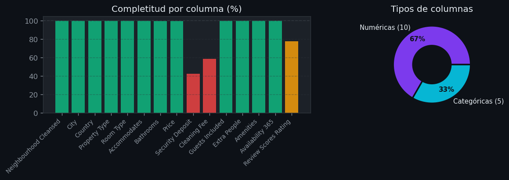

## ⚠️ Alertas — 22 problema(s) detectado(s)

🕳️ Valores Nulos6

⚠️ warning

CityContiene nulos: 6 filas (0.04%)

⚠️ warning

BathroomsContiene nulos: 55 filas (0.37%)

⚠️ warning

PriceContiene nulos: 17 filas (0.12%)

🔴 danger

Security DepositNulos críticos: 8,524 de 14,780 filas (57.7%)

⚠️ warning

Cleaning FeeContiene nulos: 6,093 filas (41.22%)

⚠️ warning

Review Scores RatingContiene nulos: 3,304 filas (22.35%)

🟡 Ceros en Variables3

🔴 danger

Extra PeopleCeros críticos: 7,598 de 14,780 valores (51.4%)

🔴 danger

AmenitiesCeros críticos: 14,164 de 14,780 valores (95.8%)

⚠️ warning

Availability 365Ceros detectados: 1,352 valores (9.1%)

⚙️ Otros13

⚠️ warning

Filas duplicadas73 filas duplicadas (0.5%)

ℹ️ info

Neighbourhood CleansedAlta cardinalidad: 478 categorías únicas

ℹ️ info

CityAlta cardinalidad: 246 categorías únicas

⚠️ warning

CountryClase dominante: 'Spain' = 94.7%

⚠️ warning

BathroomsAlta asimetría: skewness = 3.44

⚠️ warning

BathroomsOutliers IQR: 24.7% de los datos

⚠️ warning

PriceAlta asimetría: skewness = 4.36

⚠️ warning

Security DepositAlta asimetría: skewness = 2.37

⚠️ warning

Cleaning FeeAlta asimetría: skewness = 5.85

⚠️ warning

Guests IncludedAlta asimetría: skewness = 3.95

⚠️ warning

Extra PeopleAlta asimetría: skewness = 10.40

⚠️ warning

AmenitiesAlta asimetría: skewness = 4.59

⚠️ warning

Review Scores RatingAlta asimetría: skewness = -2.70

## 🕳️ Valores Nulos

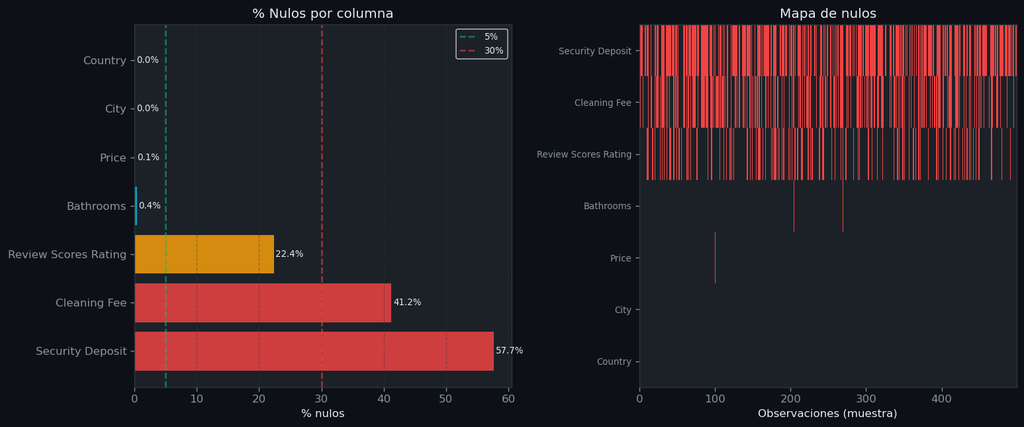

## 📋 Variables (15)

Neighbourhood Cleansed 0.0000% nulos · 478 únicos Categórica ›

| Tipo dtype | object |
| --- | --- |
| Valores no nulos | 14,780 |
| Nulos | 0 (0.0%) |
| Únicos | 478 |
| Único % | 3.2% |
| Moda | Embajadores |
| Frecuencia moda | 1,849 (12.5%) |

[output not shown]

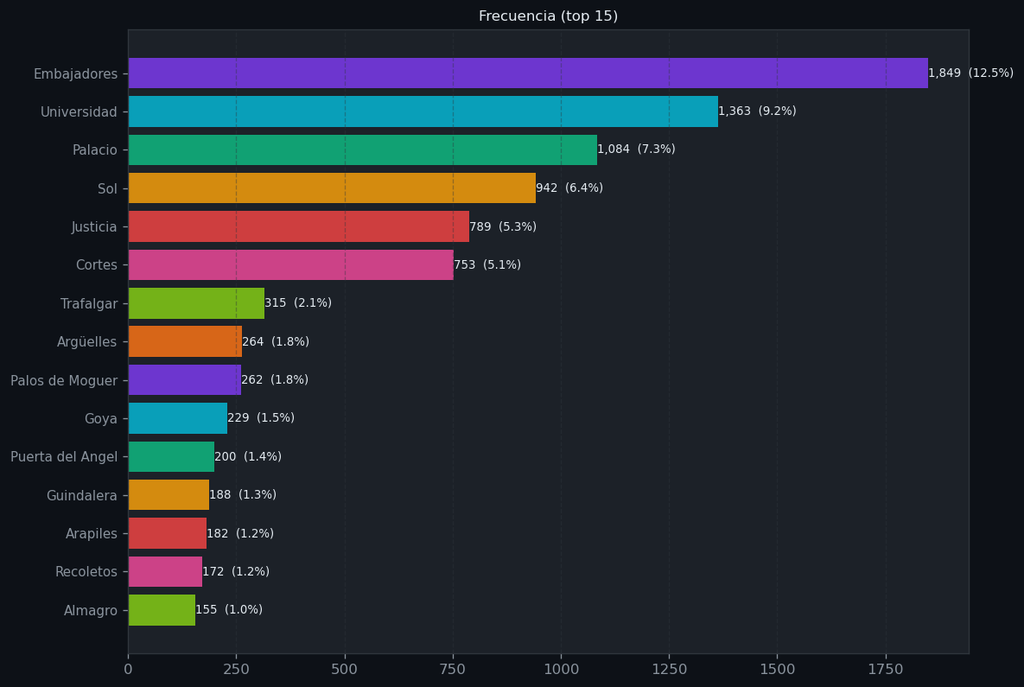

City 0.0406% nulos · 246 únicos Categórica ›

| Tipo dtype | object |
| --- | --- |
| Valores no nulos | 14,774 |
| Nulos | 6 (0.0%) |
| Únicos | 246 |
| Único % | 1.7% |
| Moda | Madrid |
| Frecuencia moda | 13,207 (89.4%) |

[output not shown]

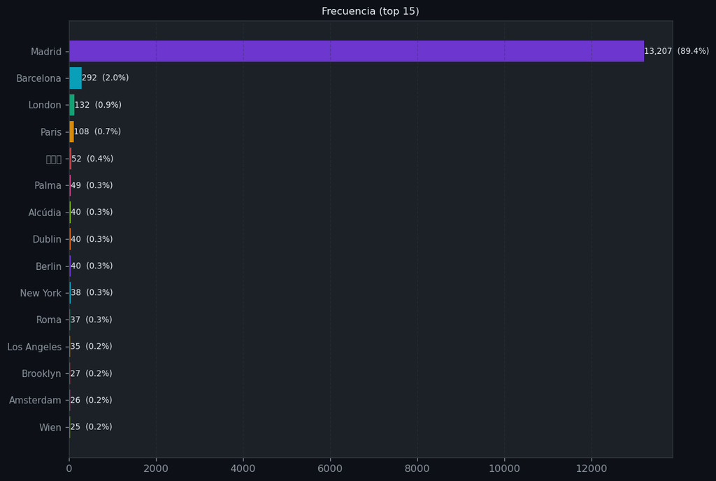

Country 0.0068% nulos · 17 únicos Categórica ›

| Tipo dtype | object |
| --- | --- |
| Valores no nulos | 14,779 |
| Nulos | 1 (0.0%) |
| Únicos | 17 |
| Único % | 0.1% |
| Moda | Spain |
| Frecuencia moda | 14,001 (94.7%) |

| Valor | Conteo | % | Freq |
| --- | --- | --- | --- |
| Spain | 14,001 | 94.7% |  |
| United States | 184 | 1.2% |  |
| United Kingdom | 159 | 1.1% |  |
| France | 110 | 0.7% |  |
| Italy | 68 | 0.5% |  |
| Australia | 46 | 0.3% |  |
| Ireland | 45 | 0.3% |  |
| Germany | 41 | 0.3% |  |
| Austria | 31 | 0.2% |  |
| Netherlands | 26 | 0.2% |  |
| Canada | 20 | 0.1% |  |
| Belgium | 17 | 0.1% |  |
| Denmark | 16 | 0.1% |  |
| Switzerland | 6 | 0.0% |  |
| Greece | 5 | 0.0% |  |

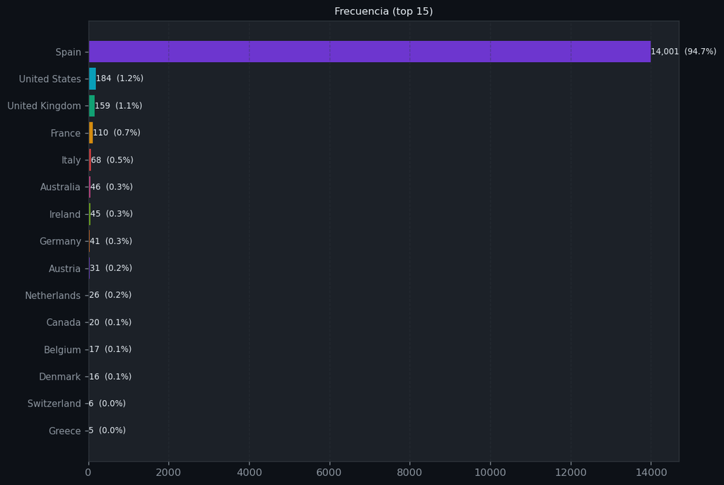

Property Type 0.0000% nulos · 22 únicos Categórica ›

| Tipo dtype | object |
| --- | --- |
| Valores no nulos | 14,780 |
| Nulos | 0 (0.0%) |
| Únicos | 22 |
| Único % | 0.1% |
| Moda | Apartment |
| Frecuencia moda | 11,962 (80.9%) |

| Valor | Conteo | % | Freq |
| --- | --- | --- | --- |
| Apartment | 11,962 | 80.9% |  |
| House | 1,368 | 9.3% |  |
| Condominium | 363 | 2.5% |  |
| Bed & Breakfast | 353 | 2.4% |  |
| Loft | 305 | 2.1% |  |
| Other | 225 | 1.5% |  |
| Dorm | 44 | 0.3% |  |
| Guesthouse | 42 | 0.3% |  |
| Chalet | 26 | 0.2% |  |
| Villa | 19 | 0.1% |  |
| Townhouse | 17 | 0.1% |  |
| Hostel | 16 | 0.1% |  |
| Serviced apartment | 13 | 0.1% |  |
| Boutique hotel | 6 | 0.0% |  |
| Boat | 4 | 0.0% |  |

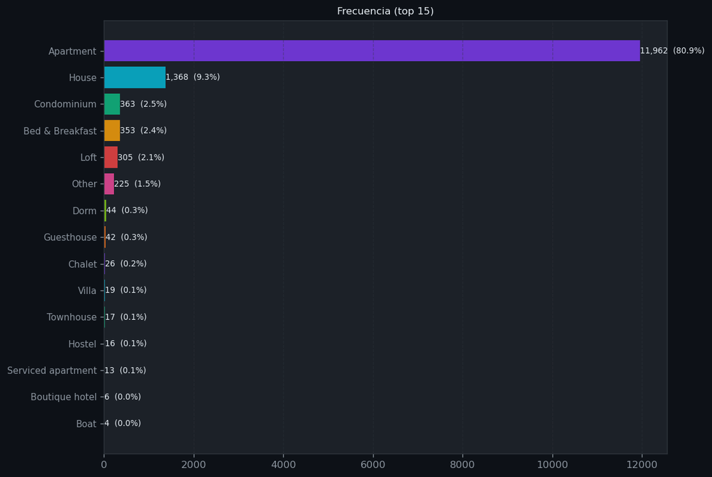

Room Type 0.0000% nulos · 3 únicos Categórica ›

| Tipo dtype | object |
| --- | --- |
| Valores no nulos | 14,780 |
| Nulos | 0 (0.0%) |
| Únicos | 3 |
| Único % | 0.0% |
| Moda | Entire home/apt |
| Frecuencia moda | 8,976 (60.7%) |

| Valor | Conteo | % | Freq |
| --- | --- | --- | --- |
| Entire home/apt | 8,976 | 60.7% |  |
| Private room | 5,595 | 37.9% |  |
| Shared room | 209 | 1.4% |  |

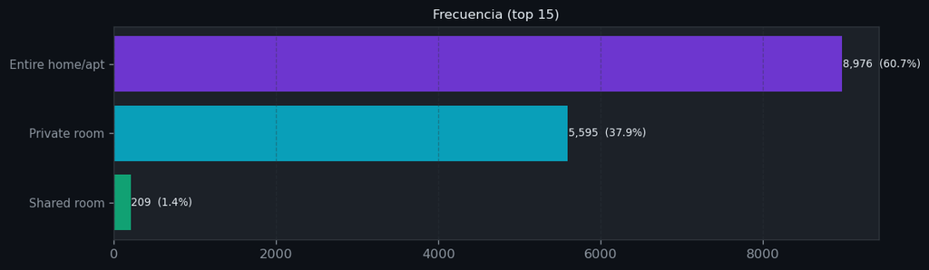

Accommodates 0.0000% nulos · 16 únicos Numérica ›

| Tipo dtype | int64 |
| --- | --- |
| Valores no nulos | 14,780 |
| Nulos | 0 (0.0%) |
| Únicos | 16 |
| Media | 3.2778 |
| Desv. estándar | 2.0973 |
| Mínimo | 1 |
| Máximo | 16 |

| p5 | 1.0000 |
| --- | --- |
| p25 (Q1) | 2.0000 |
| Mediana | 3.0000 |
| p75 (Q3) | 4.0000 |
| p95 | 7.0000 |
| IQR | 2.0000 |
| Asimetría | 1.8558 |
| Curtosis | 5.7950 |

| Ceros | 0 (0.0%) |
| --- | --- |
| Negativos | 0 |
| Outliers IQR | 659 (4.5%) |
| Normalidad (Shapiro) | ⚠️ No normal (p=0.0000) |

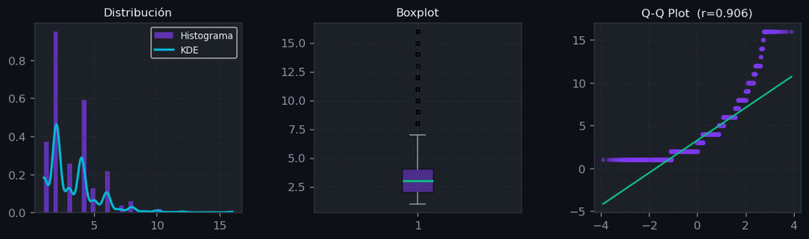

Bathrooms 0.3721% nulos · 17 únicos Numérica ›

| Tipo dtype | float64 |
| --- | --- |
| Valores no nulos | 14,725 |
| Nulos | 55 (0.4%) |
| Únicos | 17 |
| Media | 1.2817 |
| Desv. estándar | 0.6585 |
| Mínimo | 0.0000 |
| Máximo | 8.0000 |

| p5 | 1.0000 |
| --- | --- |
| p25 (Q1) | 1.0000 |
| Mediana | 1.0000 |
| p75 (Q3) | 1.0000 |
| p95 | 2.0000 |
| IQR | 0.0000 |
| Asimetría | 3.4387 |
| Curtosis | 17.5202 |

| Ceros | 66 (0.4%) |
| --- | --- |
| Negativos | 0 |
| Outliers IQR | 3,637 (24.7%) |
| Normalidad (Shapiro) | ⚠️ No normal (p=0.0000) |

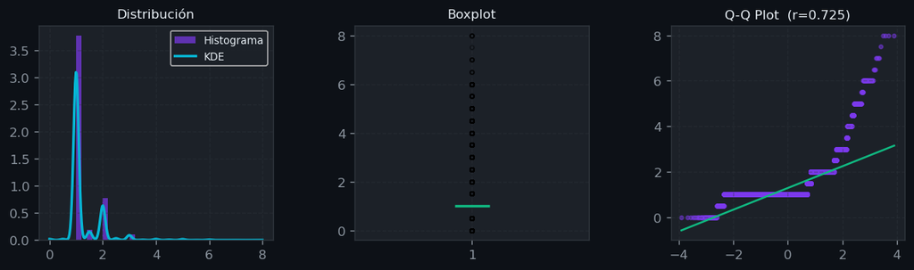

Price 0.1150% nulos · 370 únicos Numérica ›

| Tipo dtype | float64 |
| --- | --- |
| Valores no nulos | 14,763 |
| Nulos | 17 (0.1%) |
| Únicos | 370 |
| Media | 73.5615 |
| Desv. estándar | 72.0621 |
| Mínimo | 9.0000 |
| Máximo | 999.0000 |

| p5 | 19.0000 |
| --- | --- |
| p25 (Q1) | 34.0000 |
| Mediana | 55.0000 |
| p75 (Q3) | 86.0000 |
| p95 | 190.0000 |
| IQR | 52.0000 |
| Asimetría | 4.3637 |
| Curtosis | 29.7908 |

| Ceros | 0 (0.0%) |
| --- | --- |
| Negativos | 0 |
| Outliers IQR | 952 (6.4%) |
| Normalidad (Shapiro) | ⚠️ No normal (p=0.0000) |

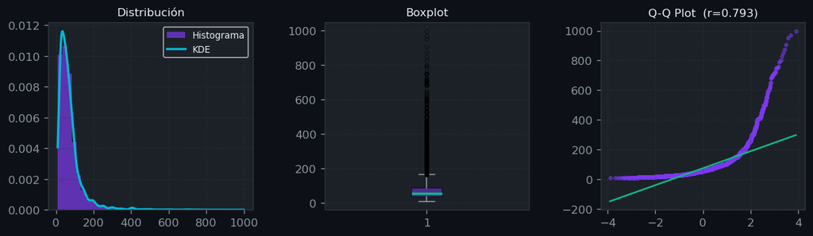

Security Deposit 57.6725% nulos · 124 únicos Numérica ›

| Tipo dtype | float64 |
| --- | --- |
| Valores no nulos | 6,256 |
| Nulos | 8,524 (57.7%) |
| Únicos | 124 |
| Media | 189.2268 |
| Desv. estándar | 115.1511 |
| Mínimo | 0.0000 |
| Máximo | 990.0000 |

| p5 | 94.0000 |
| --- | --- |
| p25 (Q1) | 100.0000 |
| Mediana | 150.0000 |
| p75 (Q3) | 200.0000 |
| p95 | 400.0000 |
| IQR | 100.0000 |
| Asimetría | 2.3739 |
| Curtosis | 7.9261 |

| Ceros | 2 (0.0%) |
| --- | --- |
| Negativos | 0 |
| Outliers IQR | 428 (6.8%) |
| Normalidad (Shapiro) | ⚠️ No normal (p=0.0000) |

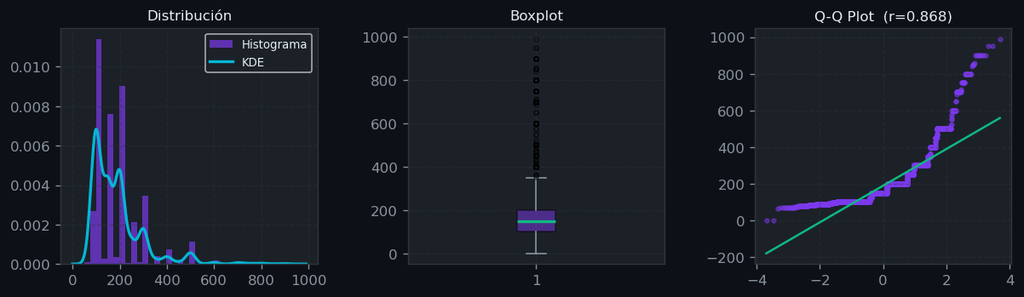

Cleaning Fee 41.2246% nulos · 111 únicos Numérica ›

| Tipo dtype | float64 |
| --- | --- |
| Valores no nulos | 8,687 |
| Nulos | 6,093 (41.2%) |
| Únicos | 111 |
| Media | 31.8053 |
| Desv. estándar | 30.8786 |
| Mínimo | 0.0000 |
| Máximo | 662.0000 |

| p5 | 6.0000 |
| --- | --- |
| p25 (Q1) | 15.0000 |
| Mediana | 25.0000 |
| p75 (Q3) | 40.0000 |
| p95 | 77.0000 |
| IQR | 25.0000 |
| Asimetría | 5.8470 |
| Curtosis | 62.3791 |

| Ceros | 1 (0.0%) |
| --- | --- |
| Negativos | 0 |
| Outliers IQR | 396 (4.6%) |
| Normalidad (Shapiro) | ⚠️ No normal (p=0.0000) |

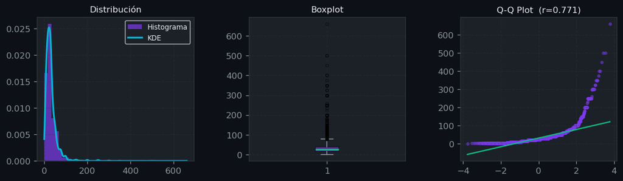

Guests Included 0.0000% nulos · 15 únicos Numérica ›

| Tipo dtype | int64 |
| --- | --- |
| Valores no nulos | 14,780 |
| Nulos | 0 (0.0%) |
| Únicos | 15 |
| Media | 1.5900 |
| Desv. estándar | 1.1826 |
| Mínimo | 0 |
| Máximo | 16 |

| p5 | 1.0000 |
| --- | --- |
| p25 (Q1) | 1.0000 |
| Mediana | 1.0000 |
| p75 (Q3) | 2.0000 |
| p95 | 4.0000 |
| IQR | 1.0000 |
| Asimetría | 3.9522 |
| Curtosis | 26.0466 |

| Ceros | 1 (0.0%) |
| --- | --- |
| Negativos | 0 |
| Outliers IQR | 1,122 (7.6%) |
| Normalidad (Shapiro) | ⚠️ No normal (p=0.0000) |

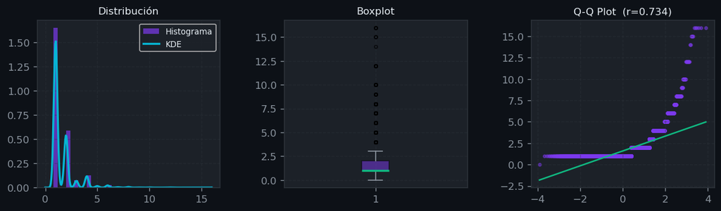

Extra People 0.0000% nulos · 68 únicos Numérica ›

| Tipo dtype | int64 |
| --- | --- |
| Valores no nulos | 14,780 |
| Nulos | 0 (0.0%) |
| Únicos | 68 |
| Media | 7.6905 |
| Desv. estándar | 12.9714 |
| Mínimo | 0 |
| Máximo | 500 |

| p5 | 0.0000 |
| --- | --- |
| p25 (Q1) | 0.0000 |
| Mediana | 0.0000 |
| p75 (Q3) | 15.0000 |
| p95 | 25.0000 |
| IQR | 15.0000 |
| Asimetría | 10.3974 |
| Curtosis | 253.6165 |

| Ceros | 7,598 (51.4%) |
| --- | --- |
| Negativos | 0 |
| Outliers IQR | 230 (1.6%) |
| Normalidad (Shapiro) | ⚠️ No normal (p=0.0000) |

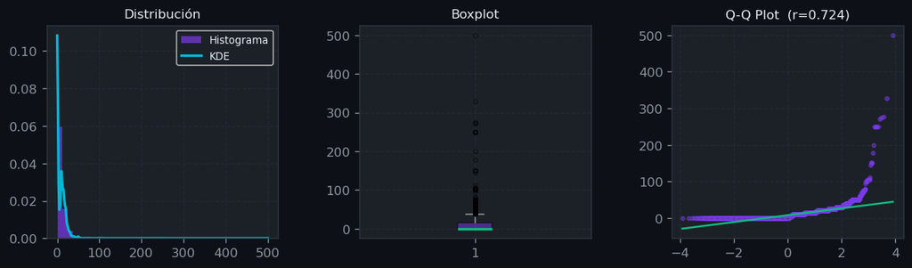

Amenities 0.0000% nulos · 2 únicos Numérica ›

| Tipo dtype | int64 |
| --- | --- |
| Valores no nulos | 14,780 |
| Nulos | 0 (0.0%) |
| Únicos | 2 |
| Media | 0.0417 |
| Desv. estándar | 0.1999 |
| Mínimo | 0 |
| Máximo | 1 |

| p5 | 0.0000 |
| --- | --- |
| p25 (Q1) | 0.0000 |
| Mediana | 0.0000 |
| p75 (Q3) | 0.0000 |
| p95 | 0.0000 |
| IQR | 0.0000 |
| Asimetría | 4.5871 |
| Curtosis | 19.0438 |

| Ceros | 14,164 (95.8%) |
| --- | --- |
| Negativos | 0 |
| Outliers IQR | 616 (4.2%) |
| Normalidad (Shapiro) | ⚠️ No normal (p=0.0000) |

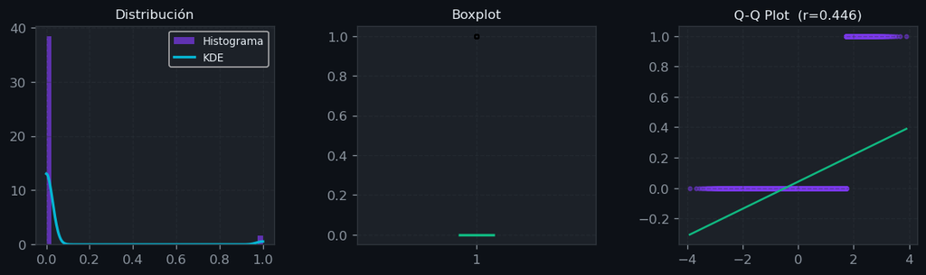

Availability 365 0.0000% nulos · 366 únicos Numérica ›

| Tipo dtype | int64 |
| --- | --- |
| Valores no nulos | 14,780 |
| Nulos | 0 (0.0%) |
| Únicos | 366 |
| Media | 202.1045 |
| Desv. estándar | 127.8868 |
| Mínimo | 0 |
| Máximo | 365 |

| p5 | 0.0000 |
| --- | --- |
| p25 (Q1) | 78.0000 |
| Mediana | 239.0000 |
| p75 (Q3) | 319.0000 |
| p95 | 364.0000 |
| IQR | 241.0000 |
| Asimetría | -0.3058 |
| Curtosis | -1.4299 |

| Ceros | 1,352 (9.1%) |
| --- | --- |
| Negativos | 0 |
| Outliers IQR | 0 (0.0%) |
| Normalidad (Shapiro) | ⚠️ No normal (p=0.0000) |

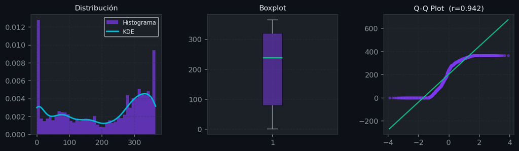

Review Scores Rating 22.3545% nulos · 54 únicos Numérica ›

| Tipo dtype | float64 |
| --- | --- |
| Valores no nulos | 11,476 |
| Nulos | 3,304 (22.4%) |
| Únicos | 54 |
| Media | 91.6980 |
| Desv. estándar | 8.9891 |
| Mínimo | 20.0000 |
| Máximo | 100.0000 |

| p5 | 78.0000 |
| --- | --- |
| p25 (Q1) | 89.0000 |
| Mediana | 94.0000 |
| p75 (Q3) | 98.0000 |
| p95 | 100.0000 |
| IQR | 9.0000 |
| Asimetría | -2.7001 |
| Curtosis | 12.9307 |

| Ceros | 0 (0.0%) |
| --- | --- |
| Negativos | 0 |
| Outliers IQR | 485 (4.2%) |
| Normalidad (Shapiro) | ⚠️ No normal (p=0.0000) |

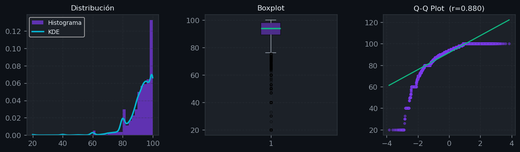

## 🔗 Correlaciones

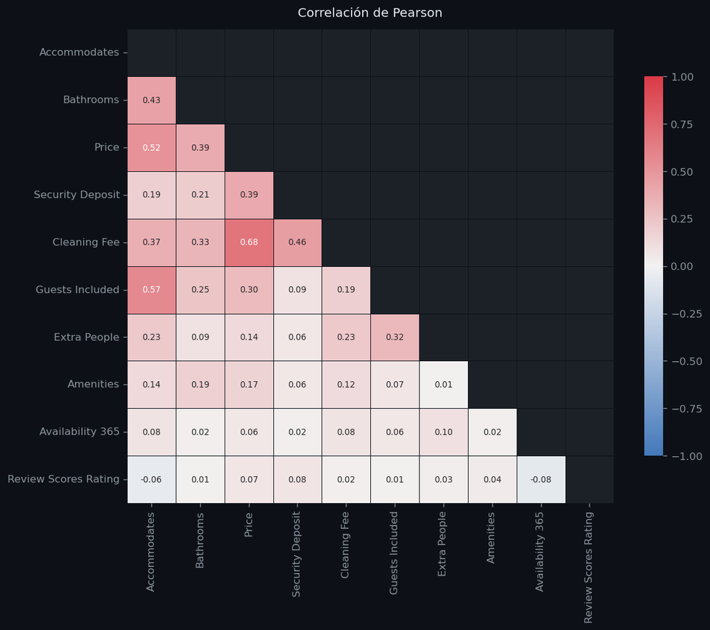

✅ No se detectaron correlaciones altas (|r| ≥ 0.70).

#### Top 15 — todas las correlaciones

| Col A | Col B | Pearson r |
| --- | --- | --- |
| Cleaning Fee | Price | **0.6819** |
| Guests Included | Accommodates | **0.5695** |
| Price | Accommodates | **0.5223** |
| Cleaning Fee | Security Deposit | **0.4579** |
| Bathrooms | Accommodates | **0.4319** |
| Security Deposit | Price | **0.3923** |
| Price | Bathrooms | **0.3870** |
| Cleaning Fee | Accommodates | **0.3660** |
| Cleaning Fee | Bathrooms | **0.3297** |
| Extra People | Guests Included | **0.3153** |
| Guests Included | Price | **0.3023** |
| Guests Included | Bathrooms | **0.2462** |
| Extra People | Accommodates | **0.2253** |
| Extra People | Cleaning Fee | **0.2253** |
| Security Deposit | Bathrooms | **0.2105** |

## 🗂️ Muestra de datos

| Neighbourhood Cleansed | City | Country | Property Type | Room Type | Accommodates | Bathrooms | Price | Security Deposit | Cleaning Fee | Guests Included | Extra People | Amenities | Availability 365 | Review Scores Rating |
| --- | --- | --- | --- | --- | --- | --- | --- | --- | --- | --- | --- | --- | --- | --- |
| 78733 | Austin | United States | Loft | Entire home/apt | 2 | 1.0 | 58.0 | 100.0 | nan | 1 | 0 | 1 | 281 | 98.0 |
| la Dreta de l'Eixample | Barcelona | Spain | Apartment | Entire home/apt | 4 | 1.0 | 70.0 | 200.0 | 40.0 | 2 | 44 | 0 | 309 | 80.0 |
| la Dreta de l'Eixample | Barcelona | Spain | Apartment | Entire home/apt | 4 | 1.0 | 70.0 | 200.0 | 60.0 | 2 | 42 | 0 | 291 | nan |
| la Dreta de l'Eixample | Barcelona | Spain | Apartment | Entire home/apt | 8 | 2.0 | 229.0 | 250.0 | 79.0 | 2 | 39 | 0 | 316 | 92.0 |
| l'Antiga Esquerra de l'Eixample | Barcelona | Spain | Apartment | Entire home/apt | 5 | 1.0 | 149.0 | nan | 55.0 | 1 | 0 | 0 | 7 | nan |
| la Nova Esquerra de l'Eixample | Barcelona | Spain | Apartment | Entire home/apt | 6 | 1.0 | 106.0 | nan | nan | 1 | 0 | 0 | 4 | nan |
| el Fort Pienc | Barcelona | Spain | Apartment | Entire home/apt | 5 | 2.0 | 52.0 | 300.0 | 60.0 | 4 | 25 | 0 | 280 | 90.0 |
| la Sagrada Família | Barcelona | Spain | Apartment | Private room | 2 | 1.0 | 45.0 | 300.0 | 30.0 | 1 | 20 | 0 | 66 | 96.0 |
| el Camp de l'Arpa del Clot | Barcelona | Spain | Apartment | Entire home/apt | 6 | 2.0 | 80.0 | nan | nan | 1 | 0 | 0 | 2 | 80.0 |
| 78703 | Austin | United States | House | Entire home/apt | 6 | 2.0 | 795.0 | nan | 250.0 | 1 | 0 | 0 | 356 | 100.0 |

| Neighbourhood Cleansed | City | Country | Property Type | Room Type | Accommodates | Bathrooms | Price | Security Deposit | Cleaning Fee | Guests Included | Extra People | Amenities | Availability 365 | Review Scores Rating |
| --- | --- | --- | --- | --- | --- | --- | --- | --- | --- | --- | --- | --- | --- | --- |
| Sineu | Sineu | Spain | House | Entire home/apt | 8 | 1.0 | 90.0 | nan | 60.0 | 6 | 20 | 1 | 348 | nan |
| Algaida | Pina | Spain | House | Entire home/apt | 2 | 2.0 | 160.0 | 100.0 | 50.0 | 1 | 70 | 0 | 365 | nan |
| Petra | Petra | Spain | House | Entire home/apt | 10 | 4.0 | 196.0 | nan | nan | 1 | 0 | 0 | 316 | 80.0 |
| Selva | Balearic Islands | Spain | House | Entire home/apt | 8 | 3.0 | 260.0 | nan | 60.0 | 1 | 0 | 1 | 284 | nan |
| Ditmars Steinway | Queens | United States | Apartment | Private room | 1 | 1.0 | 40.0 | 200.0 | nan | 1 | 0 | 0 | 0 | 80.0 |
| Bedford-Stuyvesant | Brooklyn | United States | Apartment | Entire home/apt | 2 | 1.0 | 90.0 | 150.0 | 60.0 | 1 | 0 | 0 | 339 | 95.0 |
| Vaugirard | Paris | France | Bed & Breakfast | Private room | 1 | 1.0 | 75.0 | nan | nan | 1 | 0 | 0 | 78 | nan |
| Batignolles-Monceau | Paris | France | Apartment | Entire home/apt | 5 | 1.0 | 100.0 | 400.0 | 40.0 | 3 | 10 | 0 | 97 | 94.0 |
| City Park West | Denver | United States | Apartment | Entire home/apt | 4 | 1.0 | 99.0 | 200.0 | 10.0 | 2 | 10 | 0 | 14 | 100.0 |
| Ravenna | Seattle | United States | House | Private room | 2 | 1.0 | 74.0 | 250.0 | nan | 2 | 0 | 0 | 365 | 98.0 |